# US Household income per state in the U.S

# 1 Loading the packages

```r
library(tidyverse)  # data manipulation
```

```r
library(ggplot2)    # plotting
library(here)       # data and files location
library(geojsonio)  # geodata
library(broom)      # tidy data
library(rgeos)      # map related things
library(readxl)
```

# 2 The data

This is a makeover of [Visualizing Household Income Distribution in the U.S. by State](http://www.visualcapitalist.com/household-income-distribution-u-s-state/)

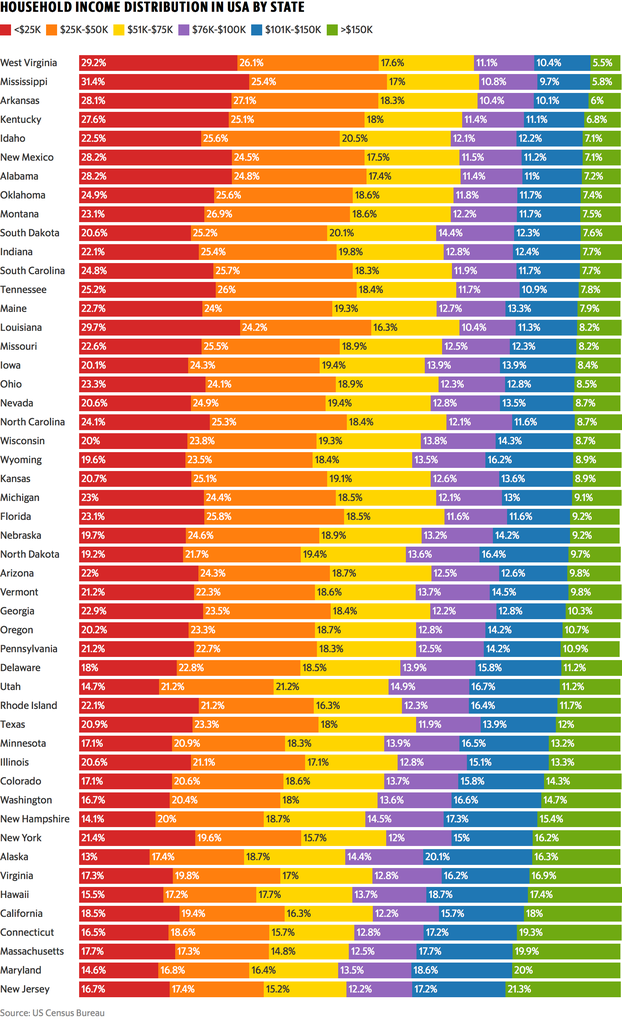

Courtesy of: [Visual Capitalist](http://www.visualcapitalist.com)

# 3 Creating a map

First I will read the hexbin in geojson format and ‘fortify’ it so I can use it with ggplot2 later The hexbin in geojson is available [here](https://team.carto.com/u/andrew/tables/andrew.us_states_hexgrid/public/map)

```r
US <- geojson_read(here('data', 'us_states_hexgrid.geojson'),  what = "sp")
US@data = US@data %>%
  mutate(google_name = gsub(" \\(United States\\)", "", google_name))

US_map <- tidy(US, region = "google_name")
```

We now have ageospatial object!!!! Next will be calculating the centroid of hexagon.

```r
centroids <- cbind.data.frame(data.frame(data.frame(gCentroid(US, byid=TRUE),
                                                    id = US@data$iso3166_2)))
```

Now we can do a bit of plotting

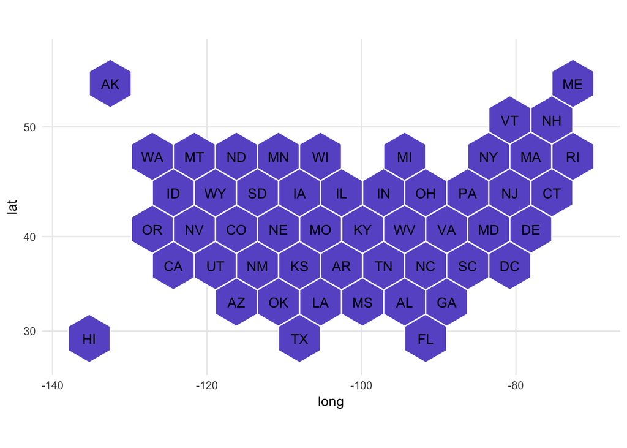

```r
ggplot() +
  geom_polygon(data = US_map, aes(x = long, y = lat, group = group),
               fill = "slateblue", color = "white") +
  geom_text(data = centroids, aes(x = x, y = y, label = id)) +
  theme_minimal() +
  coord_map()
```

My idea is to colour the hexagons according to the income data. So it is basically a [cloropeth map](https://datavizcatalogue.com/methods/choropleth.html).

So now we need to load the data and do a basic exploration before getting to integrate it with the map.

The data can be found [here](https://data.world/makeovermonday/2018-w-3-u-s-household-income-distribution-by-state)

```r
housing <- read_excel(here('data', 'household_US.xlsx'))
housing$`Income Level` <- as.factor(housing$`Income Level`)
head(housing)
```

```
## # A tibble: 6 x 5
##    Year   State     `Income Level` `Percent of Total`
##   <dbl>   <chr>             <fctr>              <dbl>
## 1  2009 Alabama $10,000 to $14,999             0.0742
## 2  2009 Alabama $15,000 to $19,999             0.0687
## 3  2009 Alabama $20,000 to $24,999             0.0661
## 4  2009 Alabama $25,000 to $29,999             0.0607
## 5  2009 Alabama $30,000 to $34,999             0.0578
## 6  2009 Alabama $35,000 to $39,999             0.0536
## # ... with 1 more variables: `Number of Households` <dbl>
```

Now that we have a fortified map and the housing data set we can start doing some interesting things.

First we’ll try and recreate the initial plot and part from there, however when inspecting the ranges for the income it is evident that we have 16 ranges!

```r
fct_count(housing$`Income Level`)
```

```
## # A tibble: 16 x 2
##                       f     n
##                  <fctr> <int>
##  1   $10,000 to $14,999   416
##  2 $100,000 to $124,999   416
##  3 $125,000 to $149,999   416
##  4   $15,000 to $19,999   416
##  5 $150,000 to $199,999   416
##  6   $20,000 to $24,999   416
##  7     $200,000 or more   416
##  8   $25,000 to $29,999   416
##  9   $30,000 to $34,999   416
## 10   $35,000 to $39,999   416
## 11   $40,000 to $44,999   416
## 12   $45,000 to $49,999   416
## 13   $50,000 to $59,999   416
## 14   $60,000 to $74,999   416
## 15   $75,000 to $99,999   416
## 16    Less than $10,000   416
```

```r
housing %>%
  group_by(Year) %>%
  summarise(income = mean(`Income Level`)) %>%
  print(housing)
```

```
## # A tibble: 8 x 2
##    Year income
##   <dbl>  <dbl>
## 1  2009     NA
## 2  2010     NA
## 3  2011     NA
## 4  2012     NA
## 5  2013     NA
## 6  2014     NA
## 7  2015     NA
## 8  2016     NA
```

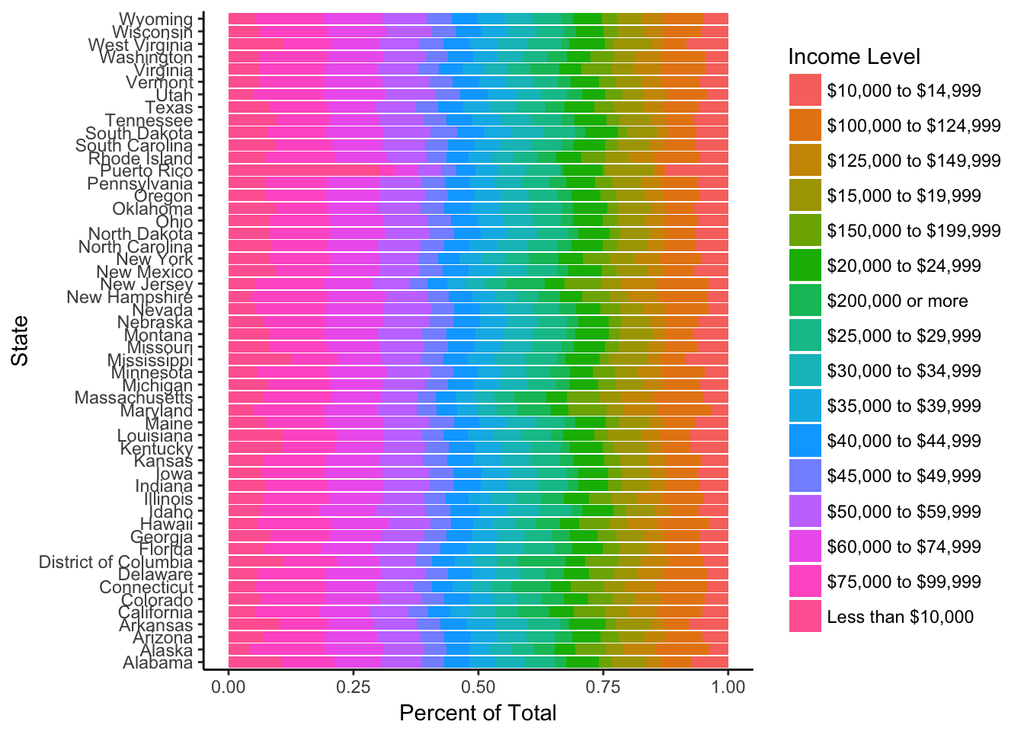

```r
housing %>%
  filter(Year == 2009) %>%
  ggplot(aes(y = `Percent of Total`, x = `State`, fill = `Income Level`)) +
  geom_bar(stat = 'identity') +
  coord_flip() +
  theme_classic()
```